# R Notebook

# 2. Null distribution

What would the distribution look like if null hypothesis were true?

mu is the population mean average rating

```r
null_distribution <- books_tidy_2020 %>%
  specify(response = average_rating) %>%
  hypothesise(null = "point", mu = 3.93) %>%
  generate(reps = 5000, type = "bootstrap")
```

# Visualise the null hypothesis distribution and the p value

P value is: assuming that the null hypothesis is true, what is the probability of observing a value at least as extreme as our observed statistic?

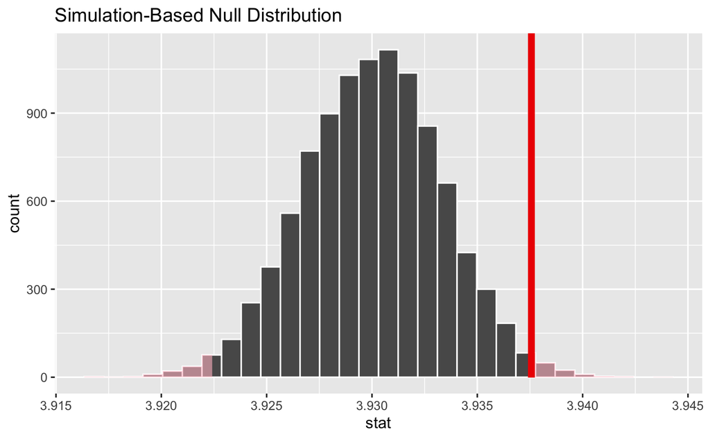

# Calculate the p value

| p_value |
| --- |
| 0.0212 |

Because the p value is lower than the alpha (0.02 < 0.05), we can reject the null hyopthesis based on this sample and accept the alternative hypothesis.

We infer from this sample that the population mean average rating in 2020 is likely to be statistically different from the average rating in 2016.

# Task

## Do books written in Spanish have a mean(average_rating) significantly less than 3.96?

# Set alpha, H0 and Ha

alpha = 0.05 H0: Spanish books average rating => 3.96. Ha: mu < 3.96 For our test: H0: mu = 3.96

# Get sample - books in Spanish

# Create a null distribution

| replicate | stat |
| --- | --- |
| 1 | 3.964856 |
| 2 | 3.949964 |
| 3 | 3.979065 |
| 4 | 3.946906 |
| 5 | 3.989460 |
| 6 | 3.975216 |
| 7 | 3.936259 |
| 8 | 3.968453 |
| 9 | 3.918273 |
| 10 | 3.923489 |

[output cut: 990 more lines]

# Visualise H0 distribution and observed stat

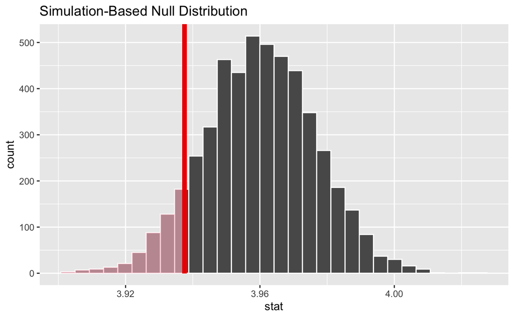

# Calculate p value

| p_value |
| --- |
| 0.0862 |

P value = 0.086. We fail to reject null hypothesis. We don’t have enough evidence to draw conclusions about the average ratings of Spanish books from this dataset